# PA1_Template

Gaurav Tiwari

May 19, 2016

## Loading and preprocessing the data

```r
activity=read.csv("activity.csv",header=TRUE)
```

Preprocessing if any required will be done during the course of the steps

## What is mean total number of steps taken per day?

For this step we need to first create a dataframe which contains the total number of steps taken by the individual in a day. We will use the aggregate function to do the summarization

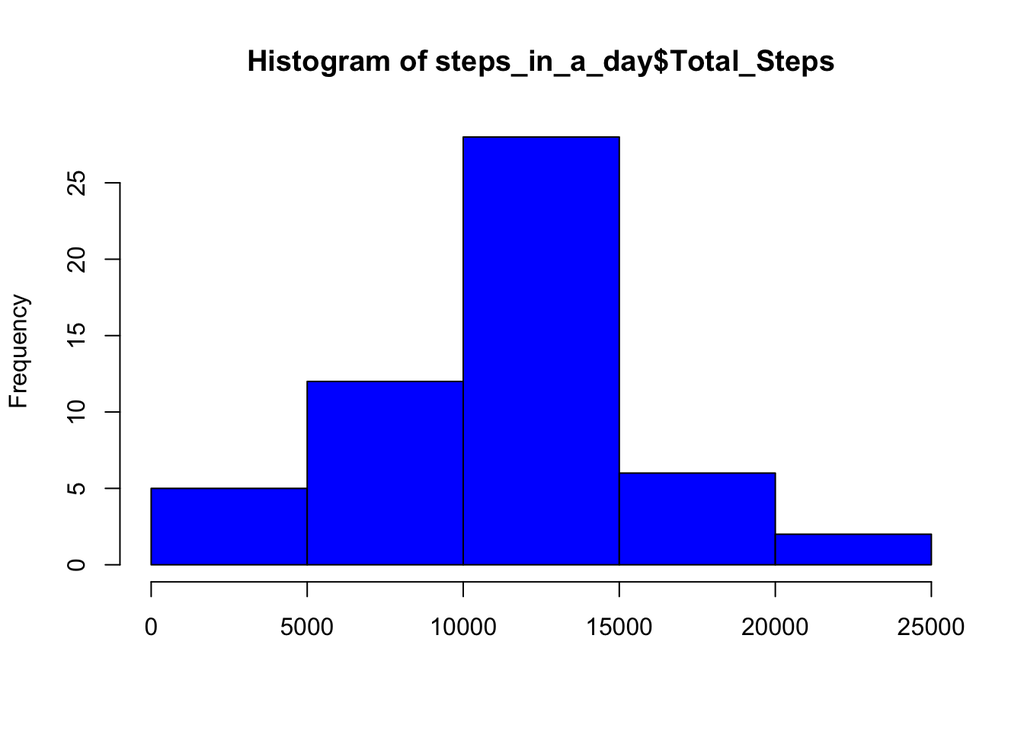

```r
steps_in_a_day =aggregate(activity$steps,list(activity$date),sum)
#Naming the columns for better workability
colnames(steps_in_a_day) = c("date","Total_Steps")

#Plotting a histogram of the total number of steps taken each day
hist(steps_in_a_day$Total_Steps,xlab ="",col="blue")
```

Mean and Median of total number of steps taken per day

```r
mean(steps_in_a_day$Total_Steps,na.rm = TRUE)
```

```
## [1] 10766.19
```

```r
median(steps_in_a_day$Total_Steps,na.rm = TRUE)
```

```
## [1] 10765
```

## What is the average daily activity pattern?

To solve this question, we will have to summarize the data but this time within the own groups of subsequent 5 minute interval.

```r
#Creating mean steps taken for each 5 minute interval throughout the period of 2 months
mean_steps_per_5_mins <- tapply(activity$steps, activity$interval, mean, na.rm=TRUE)
```

Creating a linear time series plot for the mean steps taken per 5 minutes period

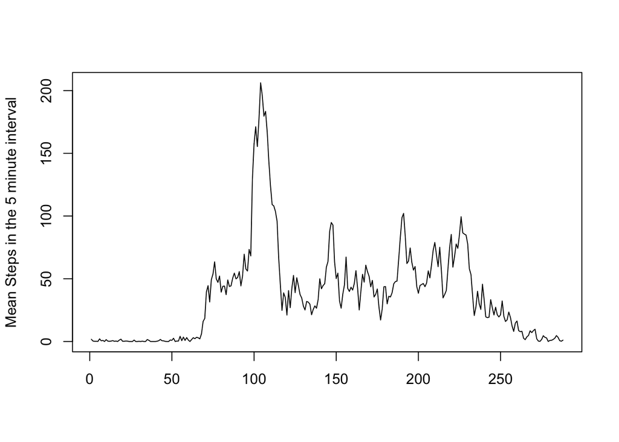

```r
plot(mean_steps_per_5_mins, type = "l", xlab = "",ylab= "Mean Steps in the 5 minute interval")
```

We can also calculate which 5 minute interval was a user most active on as follows:

```r
max_active_minute<- which.max(mean_steps_per_5_mins)
mean_steps_per_5_mins[max_active_minute]
```

```
##      835
## 206.1698
```

So the user is most active at 8:35 am taking approx. 206 steps, can relate to his office time where he is running a bit late and hence takes more steps per minute.

## Imputing missing values

There are a lot of missing values(NA) present in out data

```r
sum(is.na(activity$steps))
```

```
## [1] 2304
```

We need to devise a strategy to fill in the missing values, what we are gonna do is we will tae the mean of steps taken everyday for that 5 minute interval and repace the NAs with those values

```r
Inteval_average <- cbind(interval=activity$interval[1:length(mean_steps_per_5_mins)],mean_steps_per_5_mins)
activity_complete <- activity
activity_complete$steps[is.na(activity_complete$steps)] <- Inteval_average[as.character(activity$interval[is.na(activity$steps)]),2]
```

We can now compare the mean and median of the total steps taken per day by looking at the complete activity set and compare it with the results we obtained before

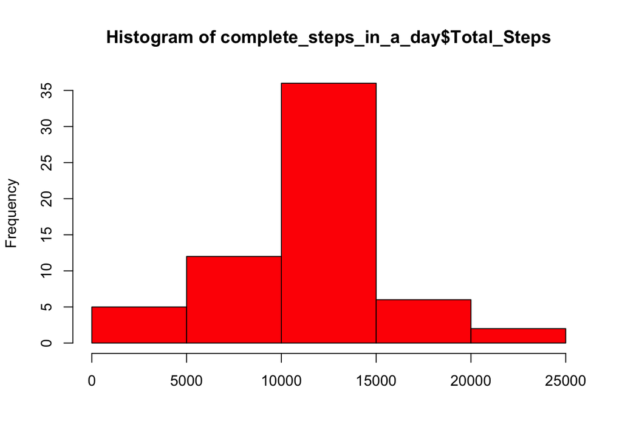

```r
complete_steps_in_a_day = aggregate(activity_complete$steps,list(activity_complete$date), sum,na.rm=TRUE)
colnames(complete_steps_in_a_day) = c("date","Total_Steps")
#Plotting the histogram
hist(complete_steps_in_a_day$Total_Steps,xlab = "",col="red")
```

```r
# Mean
mean(complete_steps_in_a_day$Total_Steps,na.rm=TRUE)
```

```
## [1] 10766.19
```

```r
# Median
median(complete_steps_in_a_day$Total_Steps,na.rm =TRUE)
```

```
## [1] 10766.19
```

## Are there differences in activity patterns between weekdays and weekends?

To see the patterns of steps taken over weekdays and weekends, we will have to split the data into 2 subsets. We will first change the date into a more standard format using the strptime function and then perfomr further computations We will then add a column to the complete data set.

```r
activity_complete$date = strptime(activity_complete$date, "%Y-%m-%d")
#Create a new column marking a day as weekend if its saturday or sunday
activity_complete$weekend <- (weekdays(activity_complete$date) == "Saturday" | weekdays(activity_complete$date) == "Sunday")

#Creating the subset for weekdays and weekend based on the new column created
weekdays <- subset(activity_complete, weekend == FALSE)
weekends <- subset(activity_complete,weekend == TRUE)

#Creating mean steps taken for each 5 minute interval throughout the period of 2 months on Weekdays
mean_steps_per_5_mins_Weekdays <- tapply(weekdays$steps, weekdays$interval, mean, na.rm=TRUE)

#Creating mean steps taken for each 5 minute interval throughout the period of 2 months on Weekdays
mean_steps_per_5_mins_Weekends <- tapply(weekends$steps, weekends$interval, mean, na.rm=TRUE)
```

Now to compare the patterns of steps taken, we will create multiple plots on the same screen for comparison

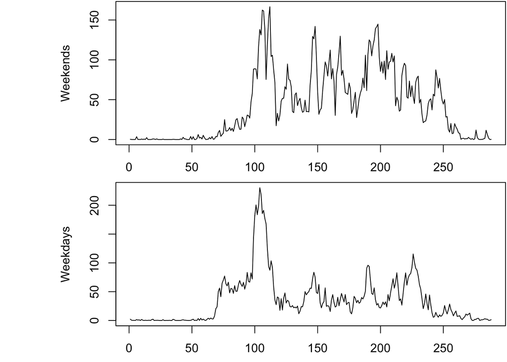

```r
par(mfrow=c(2,1),mar=c(2.5,8,0.1,0.1))
plot(mean_steps_per_5_mins_Weekends, type = "l", xlab = "",ylab= "Weekends")
plot(mean_steps_per_5_mins_Weekdays, type = "l", xlab = "",ylab= "Weekdays")
```